# Spatial data: introduction

Similar to time series data, spatial data come in at least three fundamentally different forms:

- point patterns: here, the locations carry the essential information: accidents, storms, earthquakes
- geostatistical data (fields): the measured attribute is of interest: air quality, temperature, anything that varies continuously over space
- lattice data: measured values reflect aggregates over large areas (population density per state, number of disease cases per hospital ward, average surface temperature over a 250 x 250 m grid cell), average yearly temperature increase by continent

We also ask different questions to these data:

- point patterns: are there differences in the density/intensity, or is it completely spatial random? Are there second-order effects such as repulsion or attraction between points?
- geostatistical data: can we interpolate the variable at locations where it was not measured? can we compute averages, or (temporal) trends? Can we simulate from the data generating process?
- lattice data: are neighbouring regions spatially correlated? (How) can we run regression models on them, taking into account the spatial correlation?

## geostatistical data.

Suppose we have spatial data, distributed over a 10 x 10 grid, with spacing 100 m:

```r
sq = seq(100,1000,100)
grd = expand.grid(x = sq, y = sq)
icov = exp(-as.matrix(dist(grd))/300)
set.seed(13333)
grd$z = t(rnorm(100) %*% chol(icov))
library(sf)
grd = st_as_sf(grd, coords = c("x", "y"))
grd
```

```
## Simple feature collection with 100 features and 1 field
## geometry type:  POINT
## dimension:      XY
## bbox:           xmin: 100 ymin: 100 xmax: 1000 ymax: 1000
## epsg (SRID):    NA
## proj4string:    NA
## First 10 features:
##              z         geometry
## 1  -0.48149963  POINT (100 100)
## 2  -0.31343067  POINT (200 100)
## 3  -0.70979954  POINT (300 100)
## 4   0.58971435  POINT (400 100)
## 5  -0.29526748  POINT (500 100)
## 6  -0.09983702  POINT (600 100)
## 7  -1.22844974  POINT (700 100)
## 8  -0.21483172  POINT (800 100)
## 9   0.69460214  POINT (900 100)
## 10  1.45241483 POINT (1000 100)
```

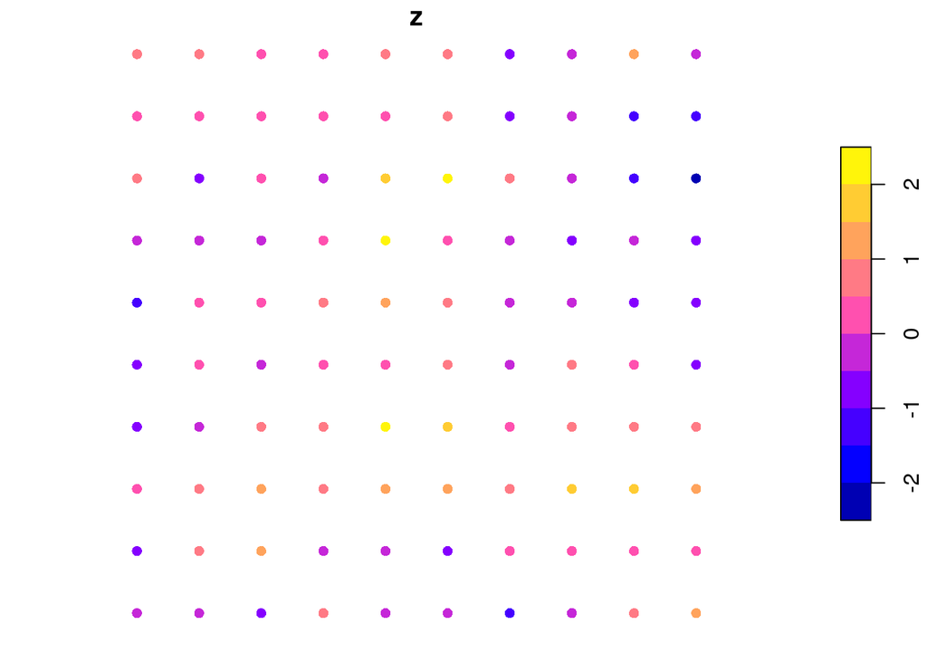

```r
plot(grd, pch = 16)
```

Suppose we are interested in the correlation of two neigbhouring locations. A difficult way would be to form a matrix of z, and shift it right and up:

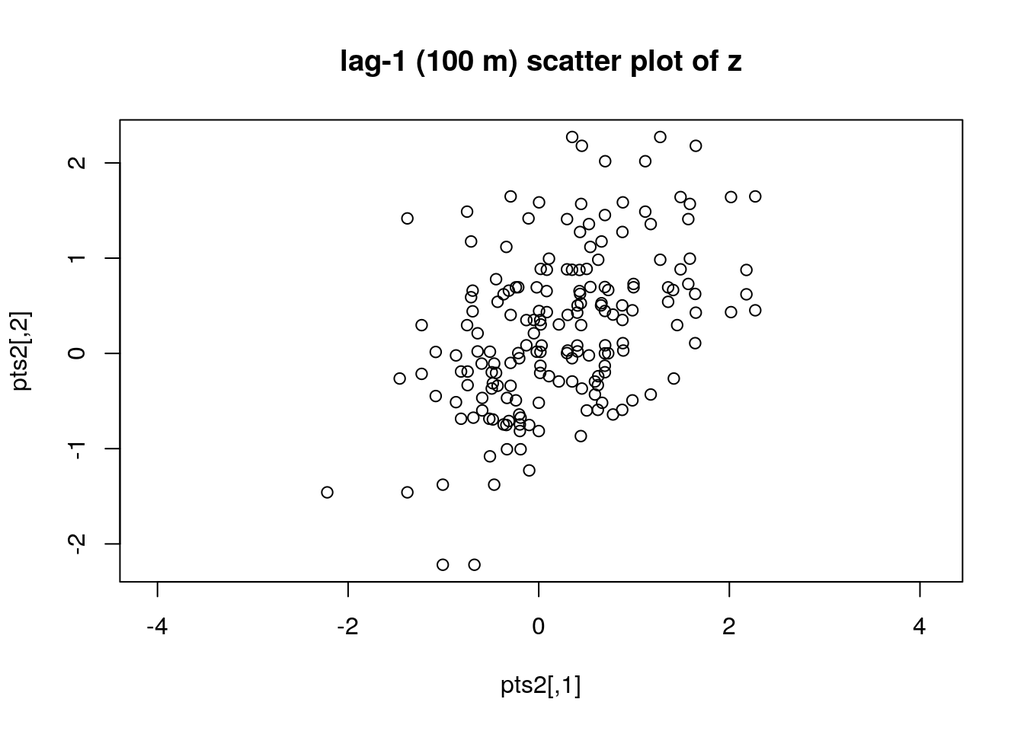

```r
m = matrix(grd$z, 10, 10)
pts1 = cbind(as.vector(m[-10,]), as.vector(m[-1,]))
pts2 = rbind(pts1, cbind(as.vector(m[,-10]), as.vector(m[,-1])))
plot(pts2, asp=1, main = "lag-1 (100 m) scatter plot of z")
```

Where clearly we see the lag-1 correlation, which in this case is a spatial correlation! We could go on like this for lag-2, lag-3 etc, but then we would miss diagonal directions:

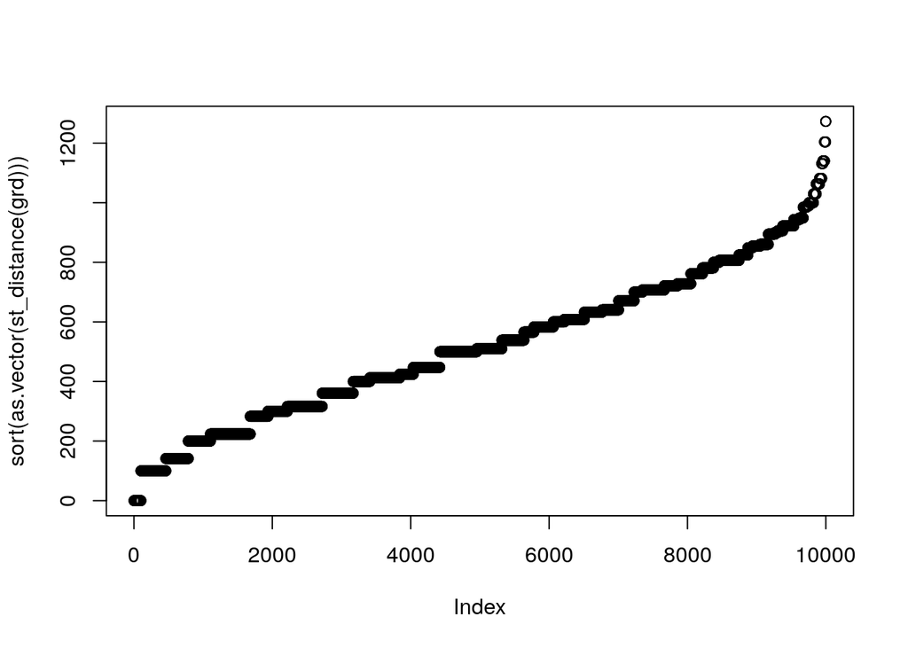

```r
plot(sort(as.vector(st_distance(grd))))
```

We can get a larger set of scatterplots, grouped by spatial distance intervals, when using gstat::hscat (lagged scatterplots):

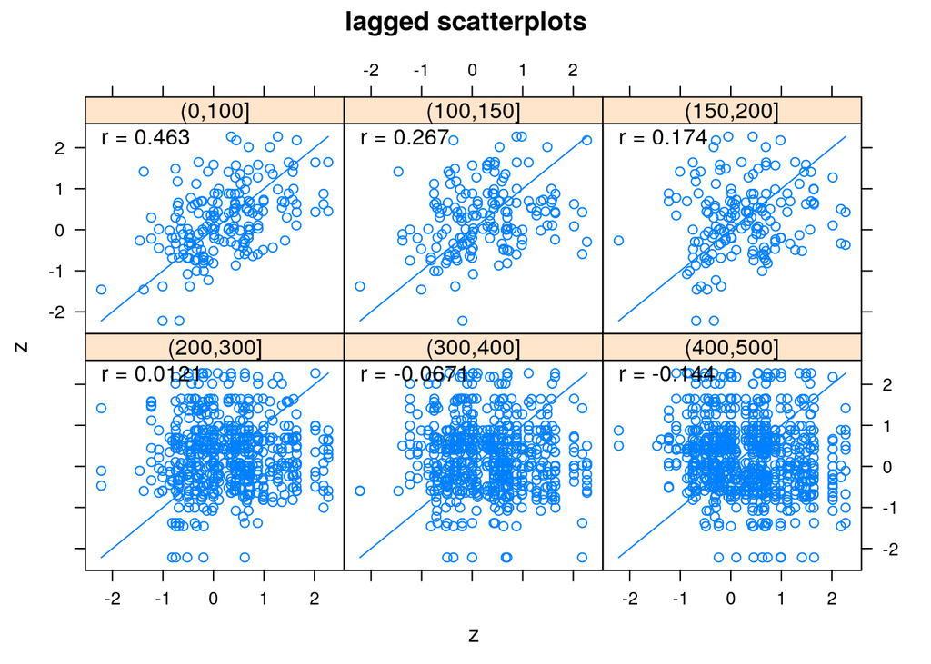

```r
library(gstat)
hscat(z~1, grd, breaks = c(0,100,150,200,300,400,500))
```

In geostatistics, rather than looking at covariances and correlations, for which the building block is
$$(z(s) - m_1)(z(s+h) - m_2)$$
we rather look at semivariances, for which the building block is
$$((z(s) - z(s+h))^2$$
In particular, the semivariance for a distance (lag) interval $h$ is defined as
$$\gamma(h) = \frac{1}{2}E((Z(s)-Z(s+h))^2)$$
and is estimated from sample data $Z(s_i)$, $i=1,...,n$ by
$$\hat{\gamma}(h) = \frac{1}{2N_h}\sum_{i=1}^{N_h}(Z(s_i)-Z(s_i+h))^2$$
where $N_h$ is the number of point pairs $\{Z(s_i),Z(s_i+h)\}$ separated by distance (interval) $h$.